# Syntax

ses

1/13/2022

# 1 Aufgaben

## 1.1 Aufgabe 1: Rope et al.

### 1.1.1 Aufgabenstellung

Im Datensatz `mtcars`: Ist der (mittlere) Unterschied im Spritverbrauch zwischen den beiden Stufen von `vs` vernachlässigbar klein?

Definieren Sie “vernachlässigbar klein” mit “höchstens eine Meile”.

1. Geben Sie die Breite des 95% PI an (im Bezug zur gesuchten Größe).
2. Geben Sie das 95% HDI an (im Bezug zur gesuchten Größe).
3. Im Hinblick auf die Rope-Methode: Ist der Unterschied vernachlässigbar klein? (ja/nein/unentschieden)

Hinweise:

- Verwenden Sie ansonsten die Standardwerte (Defaults) der typischen (im Unterricht verwendeten) R-Funktionen.
- Runden Sie auf 2 Dezimalstellen.
- Verwenden Sie Methoden der Bayes-Statistik.

### 1.1.2 Lösung

Setup:

```r
data(mtcars)
library(tidyverse)
library(rstanarm)
library(bayesplot)  # Histogramm-Plots für Post-Vert.
library(bayestestR)  # rope
```

Modell berechnen:

```r
m1 <- stan_glm(mpg ~ vs, data = mtcars,
               refresh = 0)
```

```r
coef(m1)
```

```
## (Intercept)          vs
##    16.62798     7.89934
```

zu a)

95%-PI:

```r
post_m1_vs <- posterior_interval(m1, prob = .95,
                   pars = "vs")
post_m1_vs[1]
```

```
## [1] 4.601405
```

```r
post_m1_vs[2]
```

```
## [1] 11.12883
```

Breite des Intervalls:

```r
breite <- post_m1_vs[2] - post_m1_vs[1]
breite <- breite %>% round(2)
```

Die Antwort für a) lautet also 6.53.

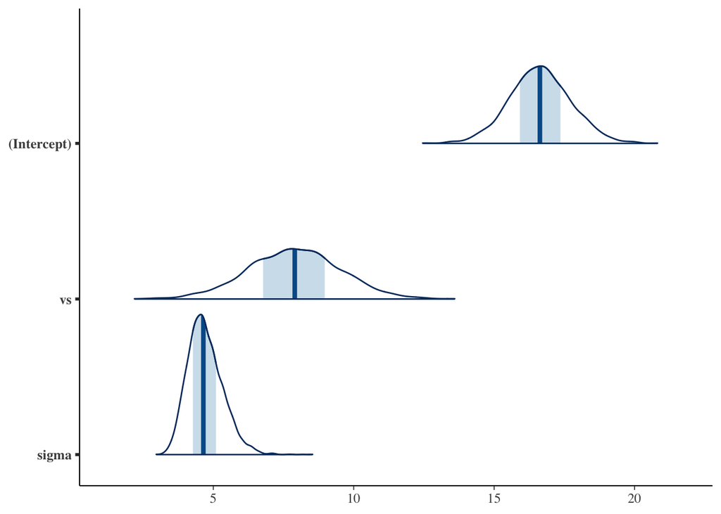

```r
mcmc_areas(m1)
```

zu b)

Wir nutzen den Befehl `hdi()` aus `{bayestestR}`.

```r
hdi(m1)
```

```
## Highest Density Interval
##
## Parameter   |        95% HDI
## ----------------------------
## (Intercept) | [14.36, 18.72]
## vs          | [ 4.72, 11.23]
```

Mit dem Schalter `ci = .89` bekäme man bspw. ein 89%-Intervall (s. Hilfe für den Befehl).

“hdi” und “hdpi” und “hpdi” sind synonym.

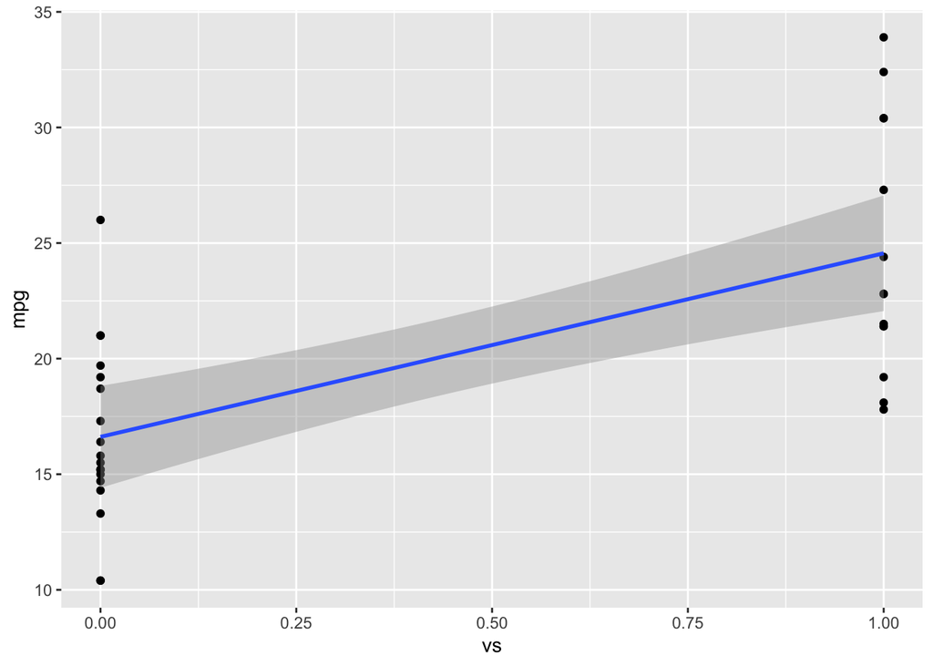

```r
ggplot(mtcars) +
  aes(x = vs, y = mpg) +
  geom_point()+
  geom_smooth(method = "lm")
```

zu c)

```r
rope(m1,range = c(-1,1))
```

```
## # Proportion of samples inside the ROPE [-1.00, 1.00]:
##
## Parameter   | inside ROPE
## -------------------------
## (Intercept) |      0.00 %
## vs          |      0.00 %
```

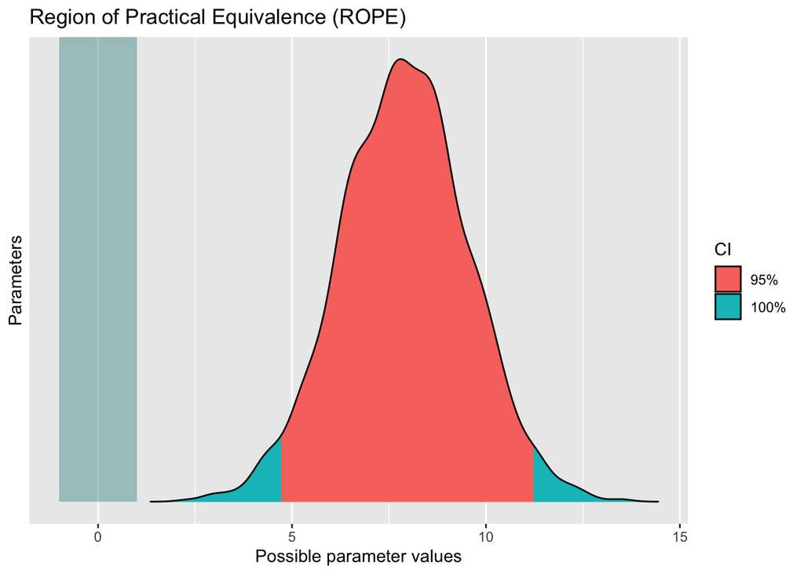

```r
plot(rope(m1, range = c(-1,1)))
```

Wir verwerfen also die H0-Rope.

## 1.2 Aufgabe 2: Covid-Stress

### 1.2.1 Aufgabenstellung

Einer der (bisher) größten Studien der Untersuchung psychologischer Konsequenzen (oder Korrelate) der Covid-Zeit ist die Studie COVIDiStress.

Im Folgenden sollen Sie folgende Forschungsfrage untersuchen:

Ist der Unterschied im Stresserleben (PSS10_avg, AV) zwischen Deutschland und Frankfrei vernachlässigbar klein? Vergleichen Sie dazu die Mittelwerte der gesuchten Größe.

Transformieren Sie die AV auf eine 0-1-Skala (“Einheitsskala”). Das heißt, der kleinst mögliche Skalenwert soll auf 0 transformiert werden und der größt mögliche 1 auf 1.

“Vernachlässigbar klein” sei definiert als höchstens 10% Unterschied (in der Einheitsskala).

Den Datensatz können Sie unter folgender URL herunterladen (Achtung, groß) als CSV-Datei:

https://osf.io/cjxua/?action=download

1. Geben Sie den Anteil der Post-Verteilung an, die außerhalb des Rope liegt.
2. Nennen Sie die Breite des 89%-Post-PI zum gesuchten Effekt.
3. Berechnen Sie den medianen Wert des Bayes-R-Quadrat.

Hinweise:

- Runden Sie auf 2 Dezimalstellen.
- Greifen Sie auf Standardwerte der typischen R-Funktionen zurück.
- Verwenden Sie Methoden der Bayes-Statistik.

## 1.3 A3

Quantile und F.werte der Norm.vert.

```r
pnorm(1)
```

```
## [1] 0.8413447
```

```r
pnorm(2)
```

```
## [1] 0.9772499
```

## 1.4 Aufgabe zur logistischen Regression

### 1.4.1 Aufgabenstellung

Wie groß ist die Wskt. für manuelles Getriebe, bei einem Auto mit 100 PS 4 Zylindern?

Berechnen Sie das einfachst mögliche logistische Modell!

Geben Sie einen Punktschätzer an!

### 1.4.2 Lösung